# Morning Practicals: Session 2

# $CO_2$ Modelling

- Load the packages and data

```r
library(mgcv); library(gamair);
data(co2s)
```

- Plot the data

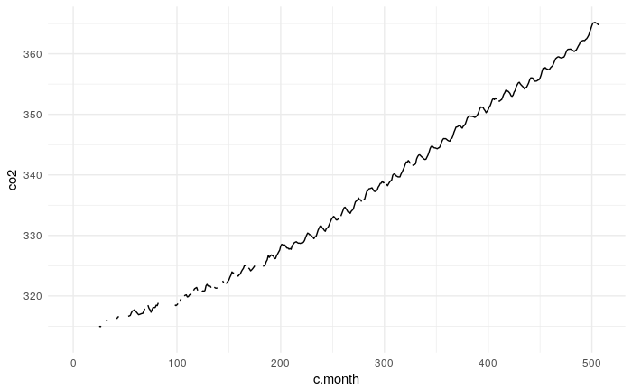

```r
library(tidyverse)
ggplot(co2s, aes(c.month, co2)) +
  geom_line() +
  theme_minimal()
```

- Fit the GAM model

```r
baseline_gam <- gam(co2 ~ s(c.month, bs = "cr", k = 100), data = co2s)
```

- Make predictions

```
Ignoring unknown aesthetics: y
```

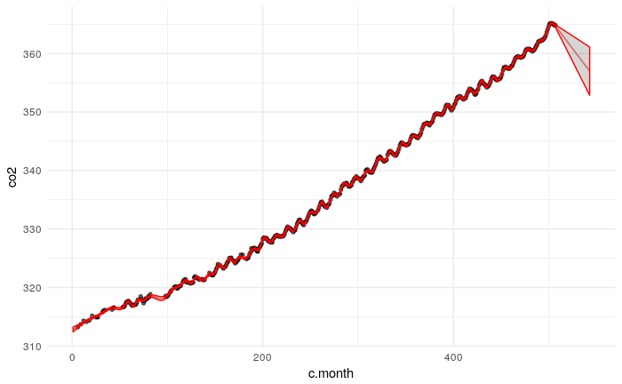

```r
pred_plot <- function(df, model) {

  preds <- predict(model ,data.frame(c.month=1:543,
                                month=c(rep(1:12,45),1:3)),
                   se=TRUE)

  out <- tibble(fit = preds$fit) %>%
    mutate(
        ul = fit + 2*preds$se,
        ll = fit - 2*preds$se,
        c.month = 1:543
    )
  ggplot(df, aes(c.month, co2)) +
  geom_point(size = 1.2, alpha = 0.6) +
  geom_line(data = out, aes(y = fit), col = "red", alpha = 0.6) +
  geom_ribbon(data = out,
              aes(x = c.month, y = fit, ymin = ll, ymax = ul),
              col = "red", alpha = 0.2) +
  theme_minimal()
}
pred_plot(co2s, baseline_gam)
```

- Fit a model with smooth functions for c.month and month (i.e months with a season effect). Use a high diemnsion for f1 and a cyclic basis for f2. Need to set knots for month to force seasons to line up correctly.

```r
seasonal_gam <- gam(co2 ~ s(c.month, bs = "cr",k = 50) + s(month,bs = "cc"),
                    data=co2s,
          knots=list(month=c(1,13)))
```

- Plot seasonal predictions

```
Ignoring unknown aesthetics: y
```

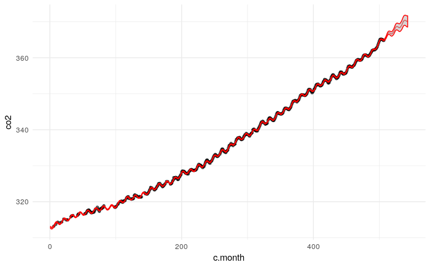

```r
pred_plot(co2s, seasonal_gam)
```

- Short term seasonality has been seperated from long term trends. This improves the extraplotion of longer term trends

# Individual electricity demand modelling solution

- Load the data and fit a basic model

```r
load( "../workshop_JGI_2018/exercises/data/Ind_elect.rda")

fit1 <- bamV(load ~ dow + ID + s(instant) + s(temp) + s(day), data = indElec,
             aViz = list(nsim = 50))

print(plot(fit1, allTerms = TRUE), pages = 1)
```

[output not shown]

- Get model summary

```r
summary(fit1)
```

```
Family: gaussian
Link function: identity

Formula:
load ~ dow + ID + s(instant) + s(temp) + s(day)

Parametric coefficients:
              Estimate Std. Error t value Pr(>|t|)
(Intercept)   0.299185   0.008380  35.704  < 2e-16 ***
dowMonday     0.032524   0.005966   5.451 5.01e-08 ***
dowSaturday  -0.014966   0.005908  -2.533 0.011299 *
dowSunday     0.004036   0.005963   0.677 0.498566
dowThursday   0.004235   0.005915   0.716 0.474044
dowTuesday    0.001096   0.005999   0.183 0.855104
dowWednesday -0.008221   0.005942  -1.384 0.166454
ID2           0.416105   0.011206  37.133  < 2e-16 ***
ID3          -0.249078   0.010498 -23.727  < 2e-16 ***
ID4          -0.217387   0.010498 -20.708  < 2e-16 ***
ID5          -0.109514   0.014450  -7.579 3.51e-14 ***
ID6           0.167023   0.010498  15.911  < 2e-16 ***
ID7          -0.105729   0.010498 -10.072  < 2e-16 ***
ID8           0.264718   0.010498  25.217  < 2e-16 ***
ID9           0.088920   0.010498   8.471  < 2e-16 ***
ID10         -0.268608   0.011383 -23.598  < 2e-16 ***
ID11         -0.165573   0.010498 -15.772  < 2e-16 ***
ID12         -0.061226   0.010498  -5.832 5.48e-09 ***
ID13         -0.140526   0.010498 -13.387  < 2e-16 ***
ID14         -0.163064   0.058799  -2.773 0.005552 **
ID15          0.229758   0.010498  21.887  < 2e-16 ***
ID16          0.092815   0.012507   7.421 1.17e-13 ***
ID17          0.028345   0.011383   2.490 0.012770 *
ID18          0.464499   0.010498  44.248  < 2e-16 ***
ID19         -0.222030   0.035078  -6.330 2.47e-10 ***
ID20         -0.049945   0.013854  -3.605 0.000312 ***
ID21         -0.093811   0.010498  -8.936  < 2e-16 ***
ID22         -0.161982   0.013962 -11.602  < 2e-16 ***
ID23         -0.224523   0.010498 -21.388  < 2e-16 ***
ID24         -0.019538   0.010498  -1.861 0.062713 .
ID25          0.201002   0.012507  16.071  < 2e-16 ***
ID26         -0.135990   0.011383 -11.947  < 2e-16 ***
ID27          0.818135   0.010498  77.936  < 2e-16 ***
ID28          0.409240   0.010498  38.984  < 2e-16 ***
---
Signif. codes:  0 ‘***’ 0.001 ‘**’ 0.01 ‘*’ 0.05 ‘.’ 0.1 ‘ ’ 1

Approximate significance of smooth terms:
             edf Ref.df      F p-value
s(instant) 8.752  8.982 497.32  <2e-16 ***
s(temp)    8.331  8.826  19.81  <2e-16 ***
s(day)     8.888  8.996  35.42  <2e-16 ***
---
Signif. codes:  0 ‘***’ 0.001 ‘**’ 0.01 ‘*’ 0.05 ‘.’ 0.1 ‘ ’ 1

R-sq.(adj) =  0.262   Deviance explained = 26.3%
fREML =  69246  Scale est. = 0.24045   n = 97772
```

- Check residuals across variables

```r
pl <- list()
pl[[1]] <- check2D(fit1, "instant", "ID") + l_gridCheck2D(bw = c(NA, 1))
```

```
check2D likes to have factor variables on x axis: I am swapping the coordinates.
```

```r
pl[[2]] <- check2D(fit1, "temp", "ID") + l_gridCheck2D(bw = c(NA, 1))
```

```
check2D likes to have factor variables on x axis: I am swapping the coordinates.
```

```r
pl[[3]] <- check2D(fit1, "day", "ID") + l_gridCheck2D(bw = c(NA, 5))
```

```
check2D likes to have factor variables on x axis: I am swapping the coordinates.
```

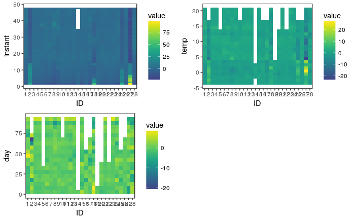

```r
library(gridExtra)
grid.arrange(grobs = lapply(pl, "[[", "ggObj"), ncol = 2)
```

- Explore problematic customers. Looks like using storage heaters?

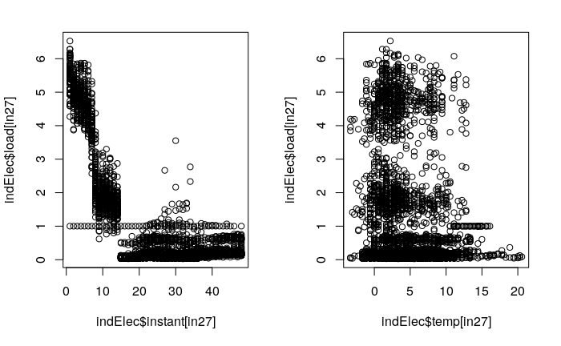

```r
in27 <- which(indElec$ID == 27)
par(mfrow = c(1, 2))
plot(indElec$instant[in27], indElec$load[in27])
plot(indElec$temp[in27], indElec$load[in27])
```

- Fit a model using BAM for individual variation

```r
summary(fit2)
```

```
Family: gaussian
Link function: identity

Formula:
load ~ dow + ID + s(instant, by = ID, id = 1) + s(temp, by = ID,
    id = 2) + s(day, by = ID, id = 3)

Parametric coefficients:
              Estimate Std. Error t value Pr(>|t|)
(Intercept)   0.263473   0.010866  24.248  < 2e-16 ***
dowMonday     0.033019   0.003248  10.165  < 2e-16 ***
dowSaturday  -0.015715   0.003209  -4.897 9.75e-07 ***
dowSunday     0.005081   0.003244   1.566  0.11734
dowThursday   0.004432   0.003212   1.380  0.16755
dowTuesday    0.003456   0.003267   1.058  0.29015
dowWednesday -0.008184   0.003233  -2.531  0.01137 *
ID2           1.042239   0.060787  17.146  < 2e-16 ***
ID3          -0.211495   0.015032 -14.069  < 2e-16 ***
ID4          -0.189642   0.015032 -12.616  < 2e-16 ***
ID5          -0.072416   0.871329  -0.083  0.93376
ID6           0.175096   0.015032  11.648  < 2e-16 ***
ID7          -0.083467   0.015032  -5.552 2.82e-08 ***
ID8           0.257744   0.015032  17.146  < 2e-16 ***
ID9           0.125601   0.015032   8.355  < 2e-16 ***
ID10         -0.162192   0.090007  -1.802  0.07155 .
ID11         -0.143106   0.015032  -9.520  < 2e-16 ***
ID12          0.003868   0.015032   0.257  0.79695
ID13         -0.129005   0.015032  -8.582  < 2e-16 ***
ID14          5.764891   9.373014   0.615  0.53852
ID15          0.232307   0.015032  15.454  < 2e-16 ***
ID16         -0.789655   0.350286  -2.254  0.02418 *
ID17          0.069730   0.090007   0.775  0.43851
ID18          0.440017   0.015032  29.271  < 2e-16 ***
ID19         -0.164369   2.531543  -0.065  0.94823
ID20         -0.227202   0.724412  -0.314  0.75380
ID21         -0.056523   0.015032  -3.760  0.00017 ***
ID22         -0.273722   0.752840  -0.364  0.71617
ID23         -0.177491   0.015032 -11.807  < 2e-16 ***
ID24         -0.058583   0.015032  -3.897 9.74e-05 ***
ID25         -0.969334   0.350286  -2.767  0.00565 **
```

[output cut: 82 more lines]

```
s(day):ID19     1.004  1.007     0.000 0.989275
s(day):ID20     4.273  4.577     2.905 0.020304 *
s(day):ID21     8.876  8.995    10.650  < 2e-16 ***
s(day):ID22     4.188  4.480     0.550 0.770502
s(day):ID23     8.876  8.995    12.540  < 2e-16 ***
s(day):ID24     8.876  8.995    22.351  < 2e-16 ***
s(day):ID25     5.626  5.928     8.016 8.88e-09 ***
s(day):ID26     7.307  7.660     0.289 0.970375
s(day):ID27     8.876  8.995    33.234  < 2e-16 ***
s(day):ID28     8.876  8.995    28.574  < 2e-16 ***
---
Signif. codes:  0 ‘***’ 0.001 ‘**’ 0.01 ‘*’ 0.05 ‘.’ 0.1 ‘ ’ 1

R-sq.(adj) =  0.782   Deviance explained = 78.4%
fREML =  11064  Scale est. = 0.070932  n = 97772
```

- Check AIC

|  | df | AIC |
| --- | --- | --- |
| fit1 | 61.51699 | 138180.88 |
| fit2 | 659.10313 | 19415.93 |

- Repeat residual checks

```r
pl <- list()
pl[[1]] <- check2D(fit2, "instant", "ID") + l_gridCheck2D(bw = c(NA, 1))
pl[[2]] <- check2D(fit2, "temp", "ID") + l_gridCheck2D(bw = c(NA, 1))
pl[[3]] <- check2D(fit2, "day", "ID") + l_gridCheck2D(bw = c(NA, 5))

library(gridExtra)
grid.arrange(grobs = lapply(pl, "[[", "ggObj"), ncol = 2)
```

[output not shown]

- Check basis functions. Basis for day and instant may be too small.

```
Method: fREML   Optimizer: perf chol
$grad
              [,1]
[1,]  1.790684e-08
[2,]  1.403322e-12
[3,] -9.090062e-11
[4,] -2.112938e-08

$hess
              [,1]        [,2]         [,3]        [,4]
[1,]   99.35701305  -0.0011219  -0.01113285  -106.76486
[2,]   -0.00112190  31.8761971   0.24853903   -73.60106
[3,]   -0.01113285   0.2485390  58.96207225   -89.04180
[4,] -106.76485926 -73.6010624 -89.04179607 48827.00000

Model rank =  790 / 790

Basis dimension (k) checking results. Low p-value (k-index<1) may
indicate that k is too low, especially if edf is close to k'.

                  k'  edf k-index p-value
s(instant):ID1  9.00 8.85    0.98   0.095 .
s(instant):ID2  9.00 8.81    0.98   0.135
s(instant):ID3  9.00 8.85    0.98   0.100 .
s(instant):ID4  9.00 8.85    0.98   0.095 .
s(instant):ID5  9.00 8.61    0.98   0.085 .
s(instant):ID6  9.00 8.85    0.98   0.115
s(instant):ID7  9.00 8.85    0.98   0.100 .
s(instant):ID8  9.00 8.85    0.98   0.110
s(instant):ID9  9.00 8.85    0.98   0.100 .
s(instant):ID10 9.00 8.80    0.98   0.085 .
s(instant):ID11 9.00 8.85    0.98   0.095 .
s(instant):ID12 9.00 8.85    0.98   0.130
s(instant):ID13 9.00 8.85    0.98   0.115
s(instant):ID14 9.00 5.38    0.98   0.110
s(instant):ID15 9.00 8.85    0.98   0.100 .
s(instant):ID16 9.00 8.73    0.98   0.120
s(instant):ID17 9.00 8.80    0.98   0.100 .
s(instant):ID18 9.00 8.85    0.98   0.105
s(instant):ID19 9.00 7.21    0.98   0.095 .
```

[output cut: 52 more lines]

```
s(day):ID16     9.00 5.63    0.94  <2e-16 ***
s(day):ID17     9.00 7.31    0.94  <2e-16 ***
s(day):ID18     9.00 8.88    0.94  <2e-16 ***
s(day):ID19     9.00 1.00    0.94  <2e-16 ***
s(day):ID20     9.00 4.27    0.94  <2e-16 ***
s(day):ID21     9.00 8.88    0.94  <2e-16 ***
s(day):ID22     9.00 4.19    0.94  <2e-16 ***
s(day):ID23     9.00 8.88    0.94  <2e-16 ***
s(day):ID24     9.00 8.88    0.94  <2e-16 ***
s(day):ID25     9.00 5.63    0.94  <2e-16 ***
s(day):ID26     9.00 7.31    0.94  <2e-16 ***
s(day):ID27     9.00 8.88    0.94  <2e-16 ***
s(day):ID28     9.00 8.88    0.94  <2e-16 ***
---
Signif. codes:  0 ‘***’ 0.001 ‘**’ 0.01 ‘*’ 0.05 ‘.’ 0.1 ‘ ’ 1
```

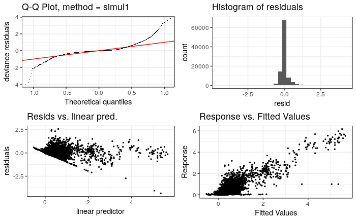

```r
check(fit2)
```

- Increase dimension and refit

|  | df | AIC |
| --- | --- | --- |
| fit2 | 659.1031 | 19415.926 |
| fit3 | 1097.5461 | 8989.751 |

- Check dimensions again

```
Method: fREML   Optimizer: perf chol
$grad
              [,1]
[1,]  1.715250e-11
[2,]  1.145750e-11
[3,]  3.769416e-10
[4,] -8.003553e-10

$hess
              [,1]         [,2]          [,3]        [,4]
[1,]  1.994108e+02   0.03839932  9.373476e-03  -230.67544
[2,]  3.839932e-02  25.60646912  1.442130e+00   -67.05466
[3,]  9.373476e-03   1.44213037  1.505795e+02  -190.84808
[4,] -2.306754e+02 -67.05466387 -1.908481e+02 48827.00000

Model rank =  1350 / 1350

Basis dimension (k) checking results. Low p-value (k-index<1) may
indicate that k is too low, especially if edf is close to k'.

                   k'   edf k-index p-value
s(instant):ID1  19.00 18.17    0.99    0.23
s(instant):ID2  19.00 17.98    0.99    0.32
s(instant):ID3  19.00 18.17    0.99    0.28
s(instant):ID4  19.00 18.17    0.99    0.29
s(instant):ID5  19.00 17.11    0.99    0.26
s(instant):ID6  19.00 18.17    0.99    0.29
s(instant):ID7  19.00 18.17    0.99    0.34
s(instant):ID8  19.00 18.17    0.99    0.23
s(instant):ID9  19.00 18.17    0.99    0.24
s(instant):ID10 19.00 17.94    0.99    0.30
s(instant):ID11 19.00 18.17    0.99    0.28
s(instant):ID12 19.00 18.17    0.99    0.27
s(instant):ID13 19.00 18.17    0.99    0.26
s(instant):ID14 19.00  8.85    0.99    0.27
s(instant):ID15 19.00 18.17    0.99    0.27
s(instant):ID16 19.00 17.63    0.99    0.28
s(instant):ID17 19.00 17.94    0.99    0.34
s(instant):ID18 19.00 18.17    0.99    0.25
s(instant):ID19 19.00 12.88    0.99    0.30
```

[output cut: 50 more lines]

```
s(day):ID14     19.00  1.00    0.99    0.30
s(day):ID15     19.00 18.06    0.99    0.32
s(day):ID16     19.00 10.49    0.99    0.38
s(day):ID17     19.00 13.97    0.99    0.30
s(day):ID18     19.00 18.06    0.99    0.36
s(day):ID19     19.00  1.19    0.99    0.27
s(day):ID20     19.00  7.95    0.99    0.29
s(day):ID21     19.00 18.06    0.99    0.31
s(day):ID22     19.00  7.77    0.99    0.30
s(day):ID23     19.00 18.06    0.99    0.34
s(day):ID24     19.00 18.06    0.99    0.29
s(day):ID25     19.00 10.49    0.99    0.31
s(day):ID26     19.00 13.97    0.99    0.33
s(day):ID27     19.00 18.06    0.99    0.37
s(day):ID28     19.00 18.06    0.99    0.34
```

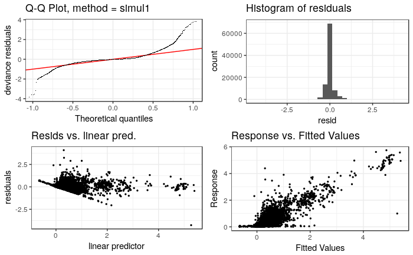

```r
check(fit3)
```

- Check relationship between individuals, load and relationship.

```
check2D likes to have factor variables on x axis: I am swapping the coordinates.
```

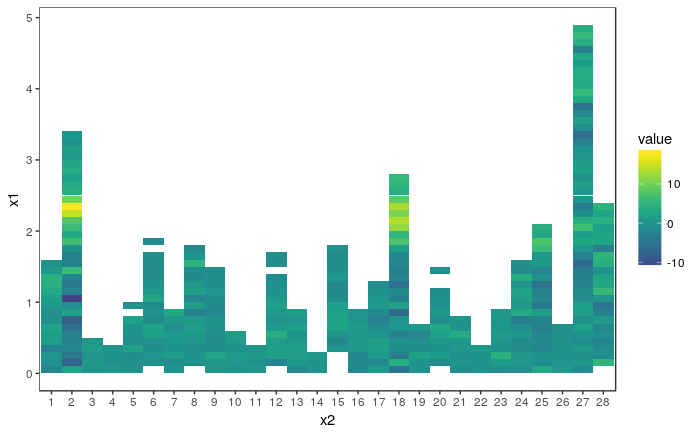

```r
check2D(fit3, indElec$load48SM, indElec$ID) + l_gridCheck2D(bw = c(NA, 0.1))
```

- Include interaction for smoothed lagged load and refit model

|  | df | AIC |
| --- | --- | --- |
| fit3 | 1097.546 | 8989.751 |
| fit4 | 1157.393 | 2661.545 |

- Check predictions on individual customers

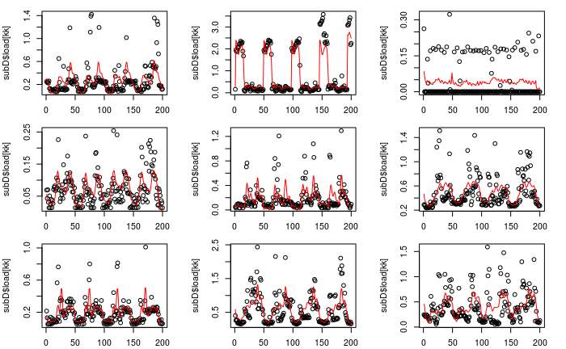

```r
par(mfrow = c(3, 3), mar = c(2.1, 4.1, 1.1, 2.1))
for(ID in 1:9){
  ids <- which( indElec$ID == ID )
  subD <- indElec[ids, ]
  subP <- fit4$fitted.values[ids]

  kk <- 1:200
  plot(subD$load[kk])
  lines(subP[kk], col = 2)
}
```

- Model is not going a good job at predicting peaks in demand in general. It is doing a particularly poor job for customer number 3.